# Model Performance Analysis

Samuel N. Araya

27 June, 2019

# RVR Model Performances

The testing set was split based on random unique combinations of date and transect without replacement into approximately 0.75:0.25 training:testing set split (i.e., 300:100 records).

The testing set was used as a hold-out set and used only to evaluate final trained models. The testing set was subset based on random unique combinations of three sampling dates and two transects without replacement. This method was adopted to ensure that the testing and training samples were not too similar because of spatial autocorrelation, which would result if a simple random splitting was done. Furthermore, to check for possible bias that may result from training:testing set split, we randomly generated 30 unique training-testing set splits and trained 30 models based on the 30 training sets and tested the model performance on their respective testing sets.

## Model Performances Summaries

### Absolute Residual of models sorted by MAE

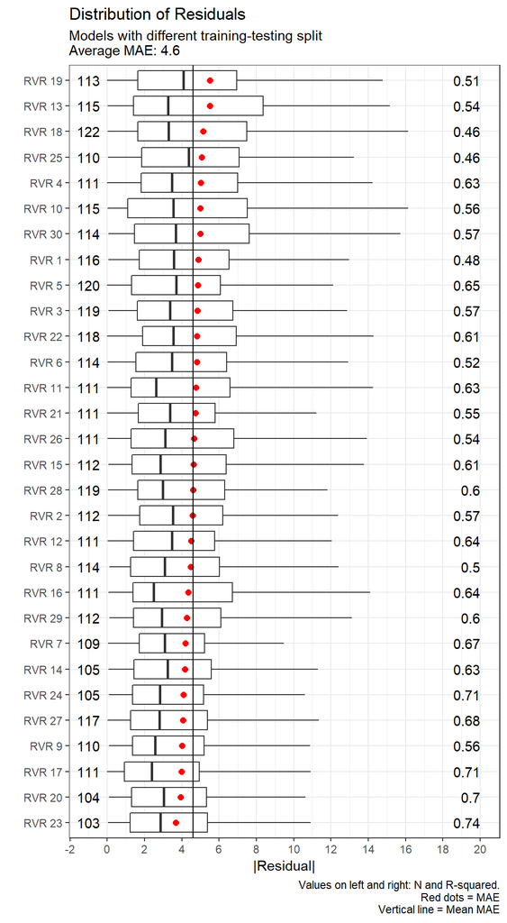

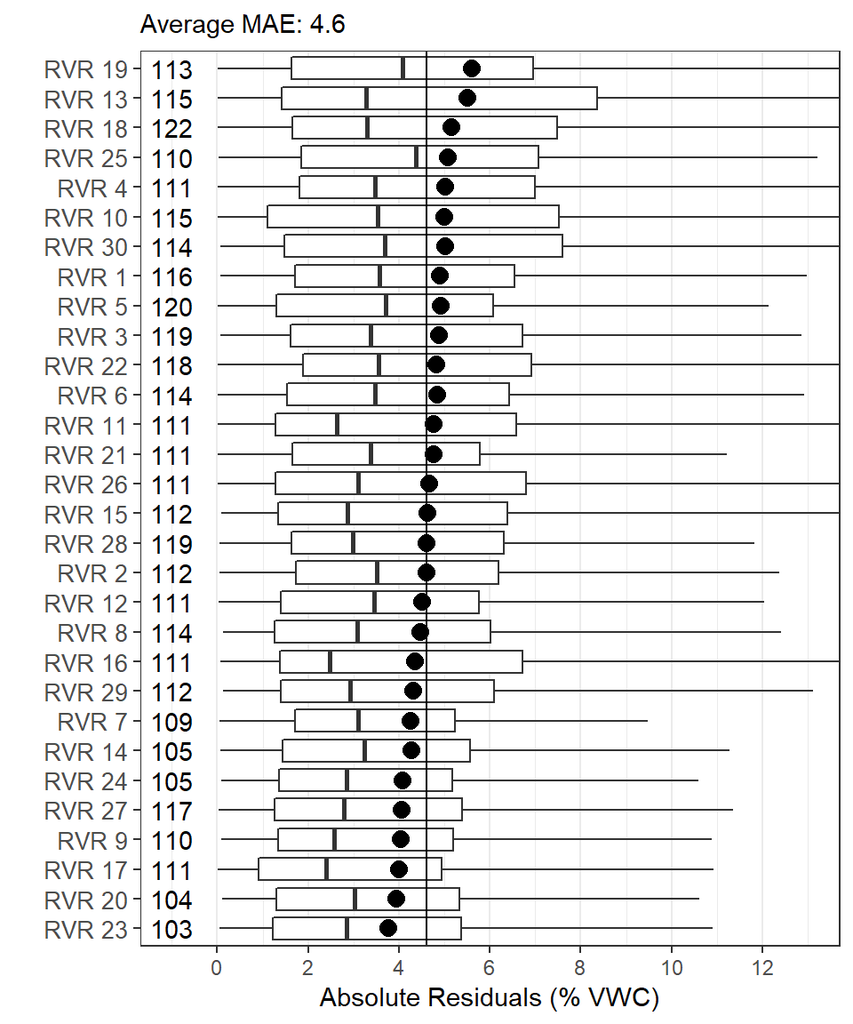

### Predicted vs. Measured Plot

Combined one to one plot with ensemble performance metrics

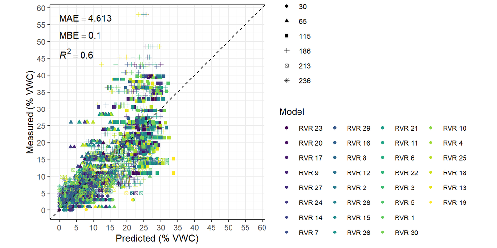

Individual models: Color plot

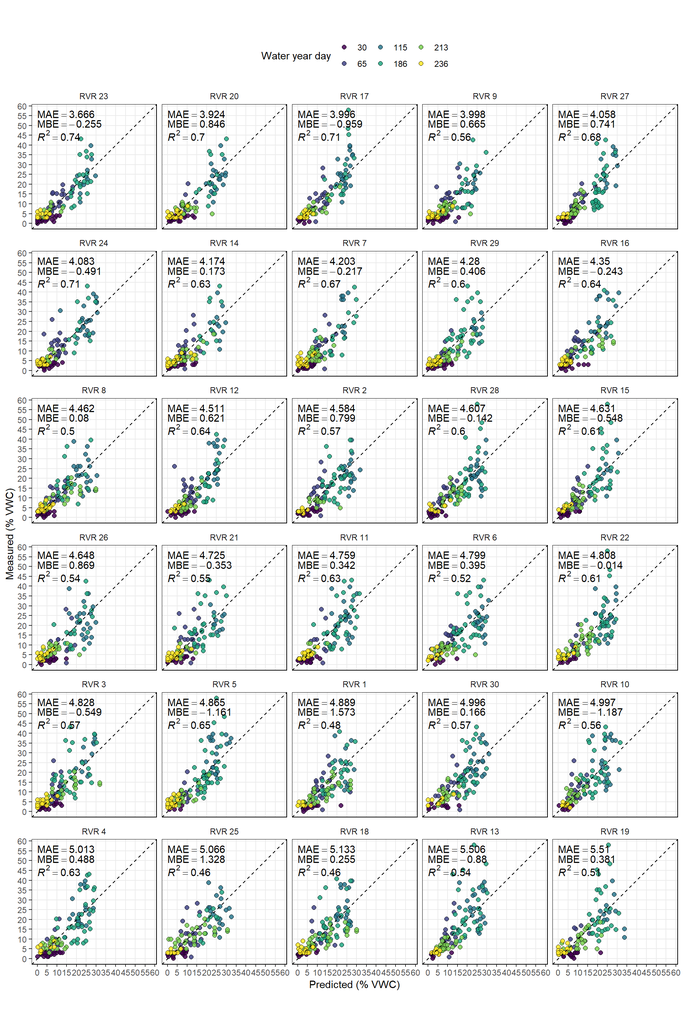

Individual models: Black and white

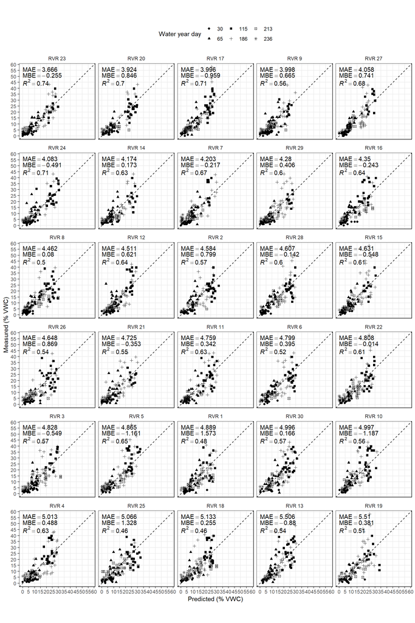

### Variable Importance

Permutation based variable importance calculated as loss from feature dropout.

Top 25 Variables

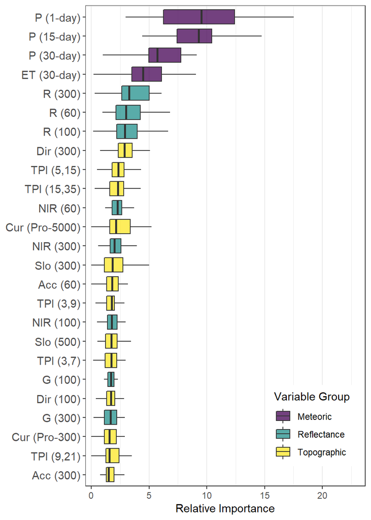

Summation of all variables grouped by type

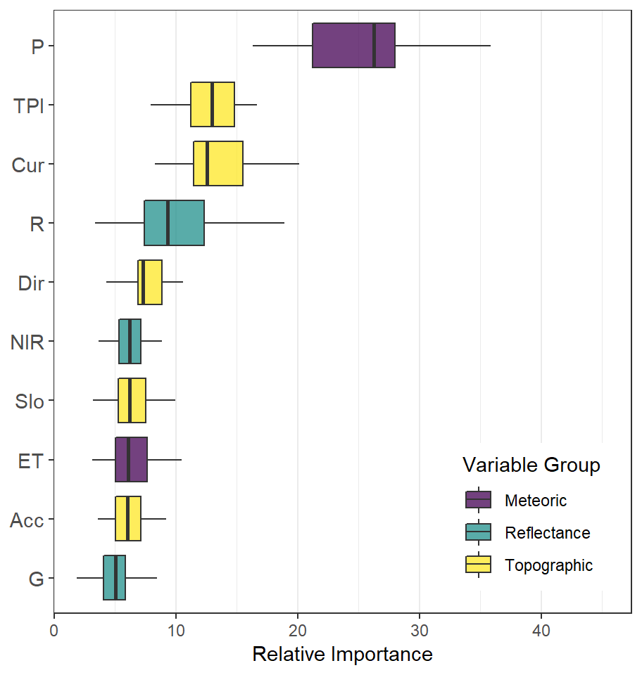

Mean of all variables grouped by type

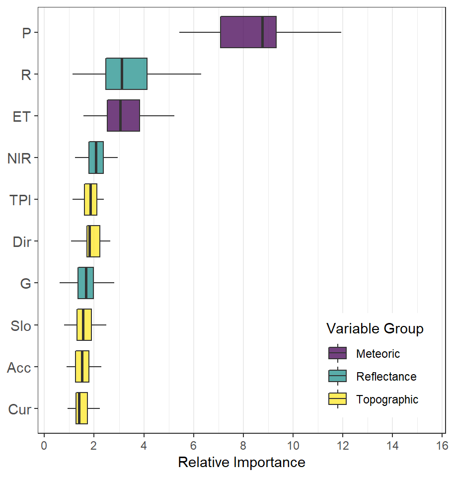

### Variable Effect

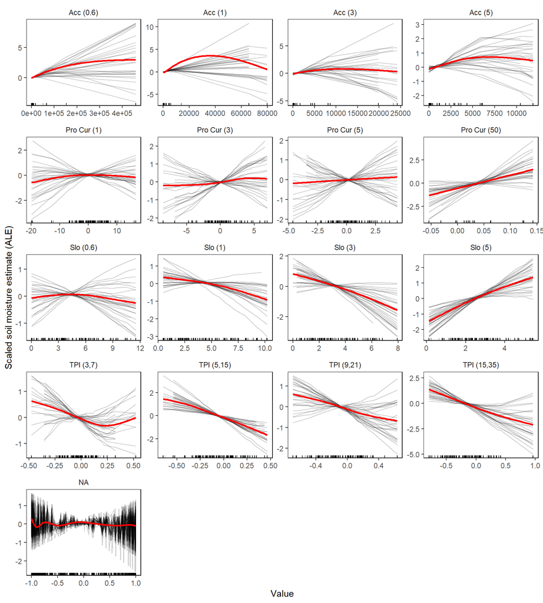

#### Tuning summaries for best models

Best tuning parameters

| id | sigma | label | label_ordered |
| --- | --- | --- | --- |
| 1 | 0.0041 | RVR 1 | RVR 1 |
| 2 | 0.0041 | RVR 2 | RVR 2 |
| 3 | 0.0066 | RVR 3 | RVR 3 |
| 4 | 0.0031 | RVR 4 | RVR 4 |
| 5 | 0.0046 | RVR 5 | RVR 5 |
| 6 | 0.0036 | RVR 6 | RVR 6 |
| 7 | 0.0061 | RVR 7 | RVR 7 |
| 8 | 0.0071 | RVR 8 | RVR 8 |
| 9 | 0.0011 | RVR 9 | RVR 9 |
| 10 | 0.0056 | RVR 10 | RVR 10 |
| 11 | 0.0036 | RVR 11 | RVR 11 |
| 12 | 0.0001 | RVR 12 | RVR 12 |
| 13 | 0.0071 | RVR 13 | RVR 13 |
| 14 | 0.0031 | RVR 14 | RVR 14 |
| 15 | 0.0036 | RVR 15 | RVR 15 |
| 16 | 0.0076 | RVR 16 | RVR 16 |
| 17 | 0.0031 | RVR 17 | RVR 17 |
| 18 | 0.0076 | RVR 18 | RVR 18 |
| 19 | 0.0036 | RVR 19 | RVR 19 |
| 20 | 0.0026 | RVR 20 | RVR 20 |
| 21 | 0.0046 | RVR 21 | RVR 21 |
| 22 | 0.0026 | RVR 22 | RVR 22 |
| 23 | 0.0051 | RVR 23 | RVR 23 |
| 24 | 0.0036 | RVR 24 | RVR 24 |
| 25 | 0.0076 | RVR 25 | RVR 25 |
| 26 | 0.0056 | RVR 26 | RVR 26 |
| 27 | 0.0006 | RVR 27 | RVR 27 |
| 28 | 0.0041 | RVR 28 | RVR 28 |
| 29 | 0.0036 | RVR 29 | RVR 29 |
| 30 | 0.0031 | RVR 30 | RVR 30 |

Tuning plots

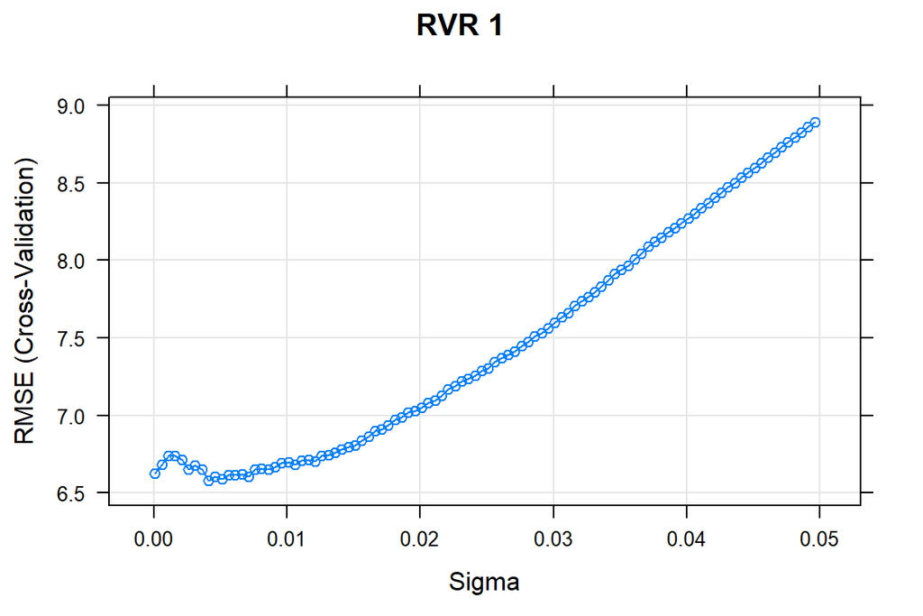

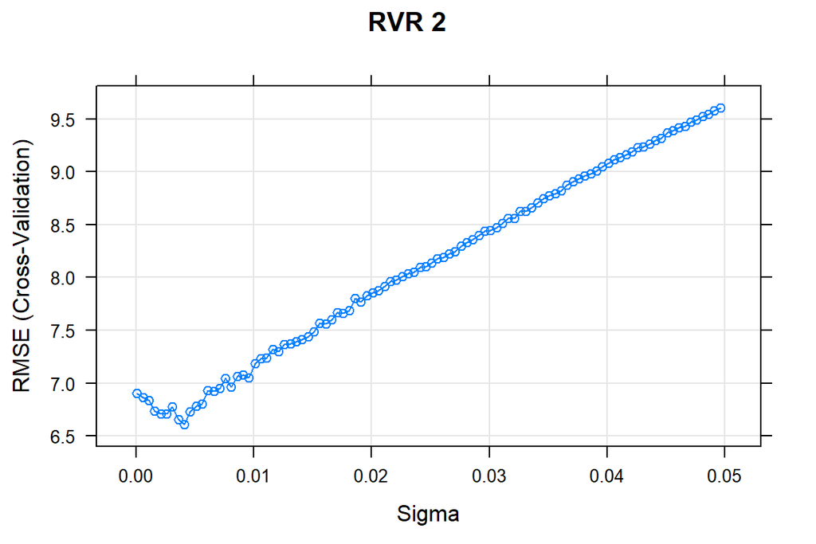

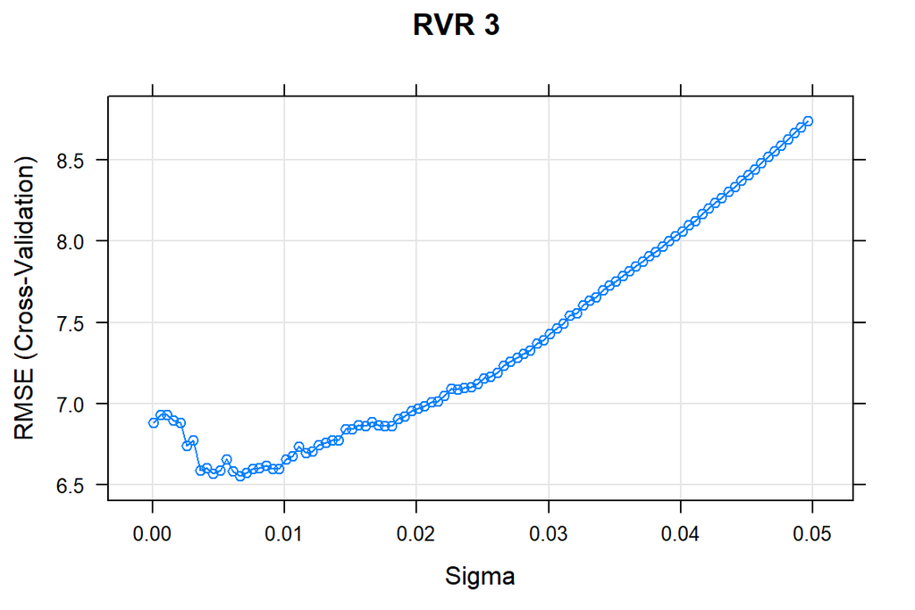

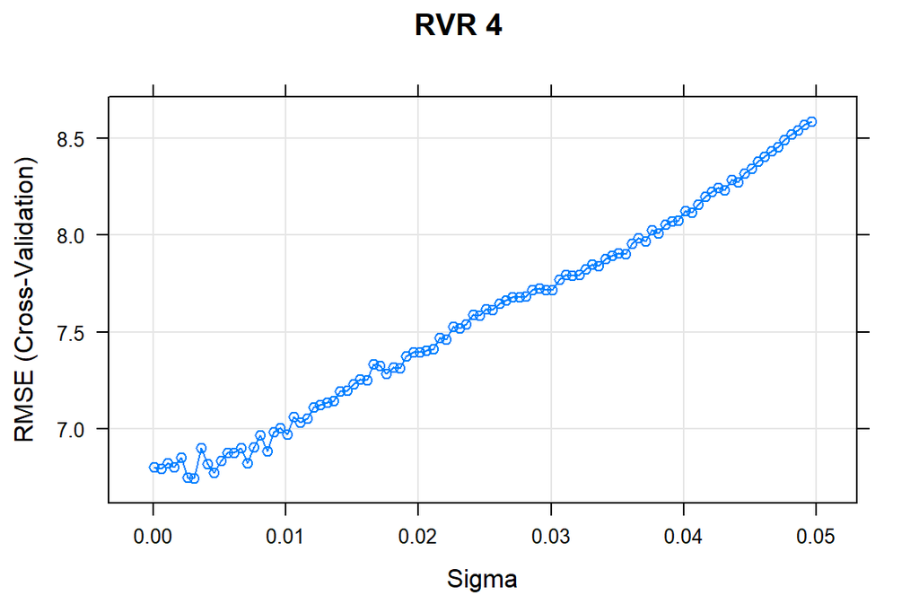

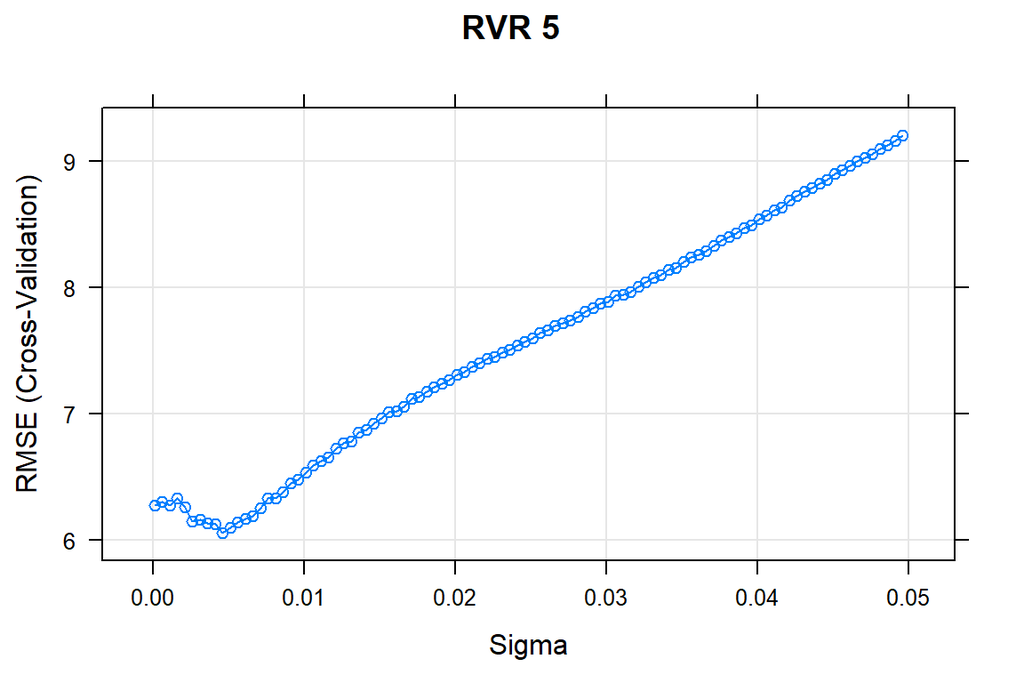

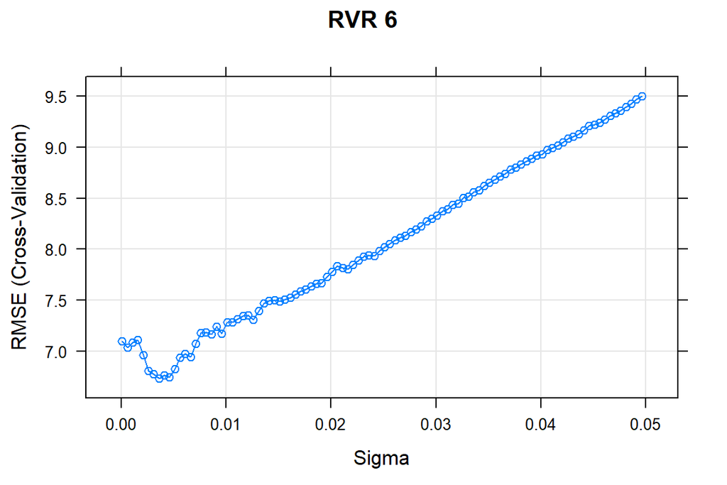

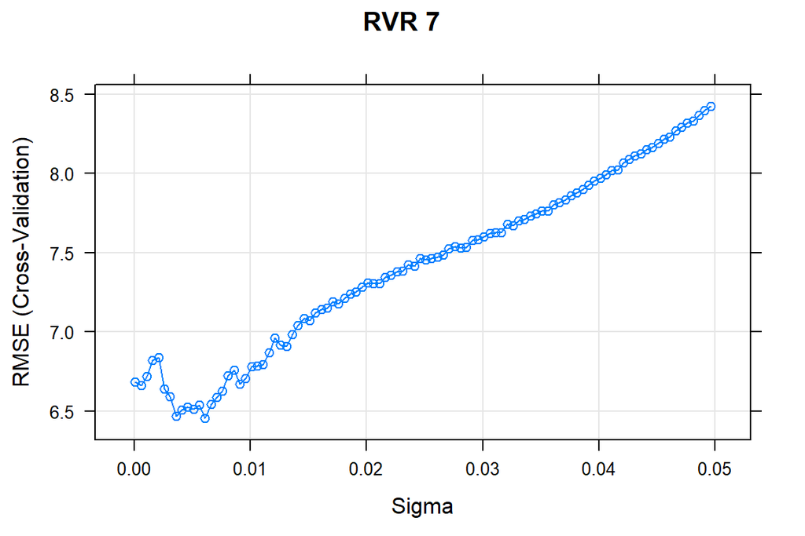

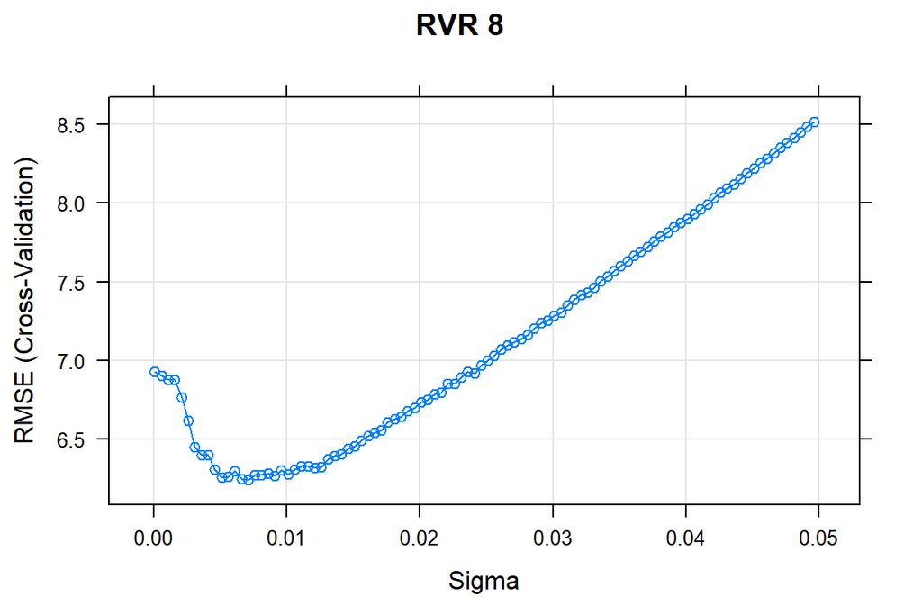

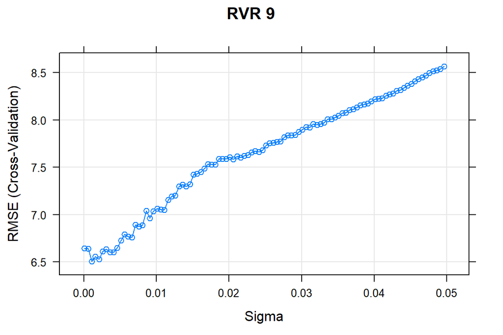

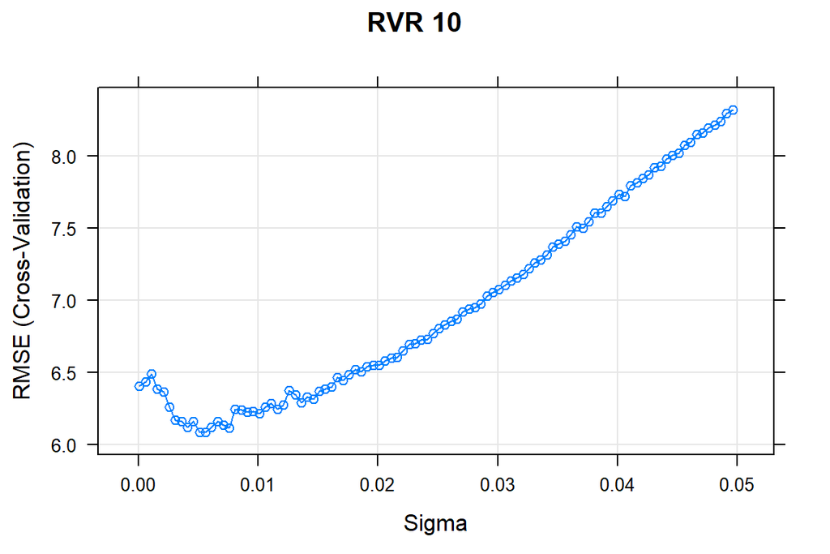

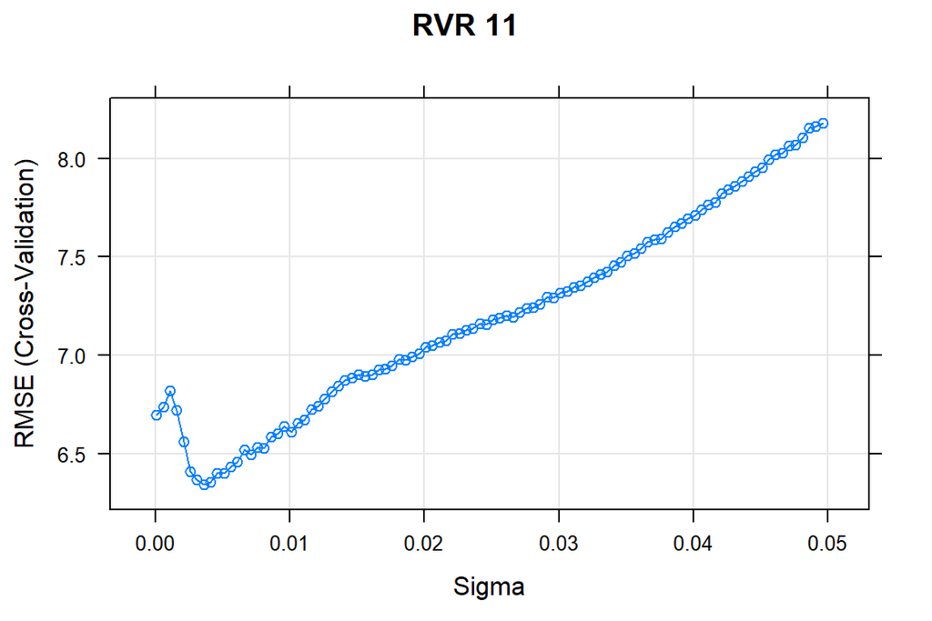

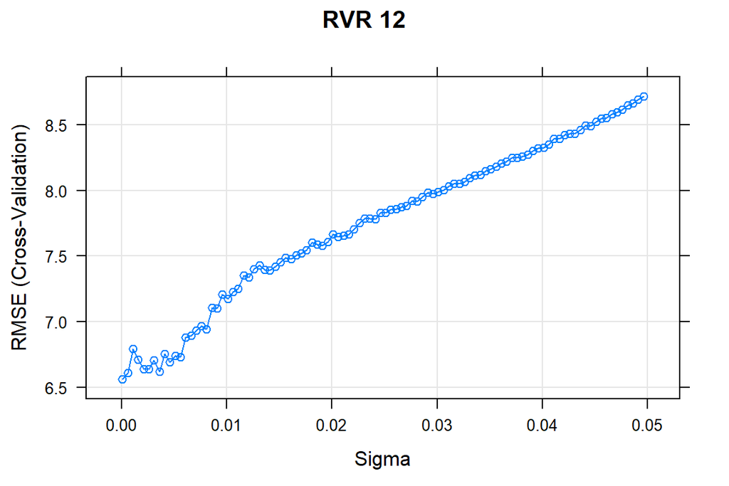

[18 more figures not shown]

## Detailed Model Performances

| label | rmse | mae | mbe | r2 | r2.fmt | n | res_q1 | res_q3 | res_iqr | mae_txt | mbe_txt | r2_txt | label_ordered |
| --- | --- | --- | --- | --- | --- | --- | --- | --- | --- | --- | --- | --- | --- |
| RVR 1 | 6.5325 | 4.8886 | 1.5733 | 0.4761 | 0.48 | 116 | -2.0064 | 5.1036 | 7.1100 | MAE==4.889 | MBE==1.573 | italic(R) ^ 2 == 0.48 | RVR 1 |
| RVR 10 | 7.0701 | 4.9967 | -1.1866 | 0.5645 | 0.56 | 115 | -3.9543 | 2.2333 | 6.1875 | MAE==4.997 | MBE==-1.187 | italic(R) ^ 2 == 0.56 | RVR 10 |
| RVR 11 | 6.6730 | 4.7586 | 0.3419 | 0.6322 | 0.63 | 111 | -2.3946 | 3.5986 | 5.9932 | MAE==4.759 | MBE==0.342 | italic(R) ^ 2 == 0.63 | RVR 11 |
| RVR 12 | 6.1996 | 4.5108 | 0.6208 | 0.6397 | 0.64 | 111 | -1.7619 | 4.5170 | 6.2789 | MAE==4.511 | MBE==0.621 | italic(R) ^ 2 == 0.64 | RVR 12 |
| RVR 13 | 8.2514 | 5.5060 | -0.8798 | 0.5423 | 0.54 | 115 | -2.8238 | 3.3594 | 6.1833 | MAE==5.506 | MBE==-0.88 | italic(R) ^ 2 == 0.54 | RVR 13 |
| RVR 14 | 5.6984 | 4.1738 | 0.1727 | 0.6318 | 0.63 | 105 | -2.4393 | 3.6270 | 6.0663 | MAE==4.174 | MBE==0.173 | italic(R) ^ 2 == 0.63 | RVR 14 |
| RVR 15 | 7.0620 | 4.6312 | -0.5480 | 0.6121 | 0.61 | 112 | -2.2939 | 3.2195 | 5.5134 | MAE==4.631 | MBE==-0.548 | italic(R) ^ 2 == 0.61 | RVR 15 |
| RVR 16 | 6.0620 | 4.3502 | -0.2428 | 0.6381 | 0.64 | 111 | -2.6377 | 2.4014 | 5.0391 | MAE==4.35 | MBE==-0.243 | italic(R) ^ 2 == 0.64 | RVR 16 |
| RVR 17 | 6.3086 | 3.9964 | -0.9586 | 0.7082 | 0.71 | 111 | -2.4986 | 2.2302 | 4.7288 | MAE==3.996 | MBE==-0.959 | italic(R) ^ 2 == 0.71 | RVR 17 |
| RVR 18 | 7.1264 | 5.1328 | 0.2553 | 0.4636 | 0.46 | 122 | -2.5100 | 3.6542 | 6.1641 | MAE==5.133 | MBE==0.255 | italic(R) ^ 2 == 0.46 | RVR 18 |
| RVR 19 | 8.0719 | 5.5100 | 0.3811 | 0.5064 | 0.51 | 113 | -2.5300 | 4.5940 | 7.1239 | MAE==5.51 | MBE==0.381 | italic(R) ^ 2 == 0.51 | RVR 19 |
| RVR 2 | 6.2062 | 4.5842 | 0.7987 | 0.5685 | 0.57 | 112 | -2.5878 | 4.1883 | 6.7760 | MAE==4.584 | MBE==0.799 | italic(R) ^ 2 == 0.57 | RVR 2 |
| RVR 20 | 5.3417 | 3.9243 | 0.8460 | 0.7049 | 0.70 | 104 | -1.9081 | 3.6965 | 5.6046 | MAE==3.924 | MBE==0.846 | italic(R) ^ 2 == 0.7 | RVR 20 |
| RVR 21 | 6.5256 | 4.7252 | -0.3533 | 0.5510 | 0.55 | 111 | -2.9611 | 3.6710 | 6.6321 | MAE==4.725 | MBE==-0.353 | italic(R) ^ 2 == 0.55 | RVR 21 |
| RVR 22 | 6.8709 | 4.8080 | -0.0141 | 0.6053 | 0.61 | 118 | -2.9979 | 3.6901 | 6.6879 | MAE==4.808 | MBE==-0.014 | italic(R) ^ 2 == 0.61 | RVR 22 |
| RVR 23 | 5.0283 | 3.6663 | -0.2546 | 0.7441 | 0.74 | 103 | -2.9431 | 2.3388 | 5.2820 | MAE==3.666 | MBE==-0.255 | italic(R) ^ 2 == 0.74 | RVR 23 |
| RVR 24 | 5.6934 | 4.0833 | -0.4913 | 0.7144 | 0.71 | 105 | -3.1522 | 2.5753 | 5.7275 | MAE==4.083 | MBE==-0.491 | italic(R) ^ 2 == 0.71 | RVR 24 |
| RVR 25 | 6.5713 | 5.0658 | 1.3285 | 0.4626 | 0.46 | 110 | -2.4726 | 5.1254 | 7.5980 | MAE==5.066 | MBE==1.328 | italic(R) ^ 2 == 0.46 | RVR 25 |
| RVR 26 | 6.4781 | 4.6482 | 0.8689 | 0.5429 | 0.54 | 111 | -2.3680 | 4.0060 | 6.3740 | MAE==4.648 | MBE==0.869 | italic(R) ^ 2 == 0.54 | RVR 26 |
| RVR 27 | 5.6502 | 4.0576 | 0.7409 | 0.6829 | 0.68 | 117 | -1.4983 | 3.6162 | 5.1145 | MAE==4.058 | MBE==0.741 | italic(R) ^ 2 == 0.68 | RVR 27 |
| RVR 28 | 6.7274 | 4.6071 | -0.1420 | 0.5984 | 0.60 | 119 | -2.8838 | 2.9440 | 5.8278 | MAE==4.607 | MBE==-0.142 | italic(R) ^ 2 == 0.6 | RVR 28 |
| RVR 29 | 6.0586 | 4.2797 | 0.4058 | 0.5953 | 0.60 | 112 | -2.1590 | 3.5543 | 5.7133 | MAE==4.28 | MBE==0.406 | italic(R) ^ 2 == 0.6 | RVR 29 |
| RVR 3 | 6.7568 | 4.8278 | -0.5487 | 0.5663 | 0.57 | 119 | -3.3253 | 3.4638 | 6.7891 | MAE==4.828 | MBE==-0.549 | italic(R) ^ 2 == 0.57 | RVR 3 |
| RVR 30 | 6.6805 | 4.9957 | 0.1659 | 0.5686 | 0.57 | 114 | -3.3219 | 3.9393 | 7.2612 | MAE==4.996 | MBE==0.166 | italic(R) ^ 2 == 0.57 | RVR 30 |
| RVR 4 | 6.6596 | 5.0131 | 0.4881 | 0.6296 | 0.63 | 111 | -2.0577 | 4.4444 | 6.5020 | MAE==5.013 | MBE==0.488 | italic(R) ^ 2 == 0.63 | RVR 4 |
| RVR 5 | 7.1015 | 4.8649 | -1.1615 | 0.6509 | 0.65 | 120 | -4.0046 | 2.8601 | 6.8647 | MAE==4.865 | MBE==-1.161 | italic(R) ^ 2 == 0.65 | RVR 5 |
| RVR 6 | 6.5907 | 4.7992 | 0.3954 | 0.5243 | 0.52 | 114 | -3.2495 | 3.9932 | 7.2427 | MAE==4.799 | MBE==0.395 | italic(R) ^ 2 == 0.52 | RVR 6 |
| RVR 7 | 5.6439 | 4.2026 | -0.2169 | 0.6659 | 0.67 | 109 | -3.0040 | 3.3585 | 6.3625 | MAE==4.203 | MBE==-0.217 | italic(R) ^ 2 == 0.67 | RVR 7 |
| RVR 8 | 6.3040 | 4.4620 | 0.0797 | 0.5002 | 0.50 | 114 | -3.1969 | 2.9085 | 6.1054 | MAE==4.462 | MBE==0.08 | italic(R) ^ 2 == 0.5 | RVR 8 |
| RVR 9 | 5.5735 | 3.9980 | 0.6650 | 0.5608 | 0.56 | 110 | -2.0873 | 3.1190 | 5.2063 | MAE==3.998 | MBE==0.665 | italic(R) ^ 2 == 0.56 | RVR 9 |